# Comparing Precincts Across Two Elections

Precinct names and precinct lines drift independently, so a precinct that swung may be a precinct that moved

Democracy’s Data

Last updated September 13, 2026 at 10:53a EDT

Every account of an election contains sentences like *turnout in this precinct fell nine points*, or *this precinct swung twelve to the challenger*. They read like measurements, and each carries a second claim that is never stated and almost never checked: that “this precinct” is the same piece of ground in both elections. **Can you compare a precinct with itself four years later?**

Often you cannot, and Houston County, Georgia (Warner Robins, Perry, and 163,633 people in 16 precincts) shows why. Between the 2020 and 2024 presidential elections, 3 of its precinct names disappeared and a precinct that had never existed appeared. Nothing in either year’s file records what any change was: the 2024 map does not say what it replaced, and no county has to announce that it moved a line.

The stakes are larger than one county’s bookkeeping. The precinct is the smallest unit at which American voting can be observed, and everything fine-grained is built on it: voting-rights analysis, campaign targeting, journalism about which neighborhoods shifted. And counties split precincts where population grows, so the places most likely to be miscompared are exactly the fast-changing suburbs coverage cares about most. An error of this kind does not look like an error. It looks like a finding.

## The test

Three files answer it, from three different publishers. The precinct boundaries belong to Georgia’s Legislative and Congressional Reapportionment Office, which posts a statewide precinct map for each general election (https://www.legis.ga.gov/joint-office/reapportionment) as a shapefile — the standard computer-readable map format, in which each precinct is a shape with a row of data attached.[^1] The two read here are the 2,684-precinct map of 2020 and the map that replaced it in 2024. The population belongs to the Census Bureau: 232,717 Georgia census blocks — the smallest areas the Bureau reports, often a single city block — from TIGER/Line 2020, the Bureau’s own map files, carrying the 2020 census count.[^2] The votes belong to the Secretary of State’s certified precinct returns for November 2020.

Why this data can answer: the precinct sits at the bottom of the ladder of election reporting, the finest rung published statewide, and the levels-of-aggregation chapter walks that ladder. This brief asks the question that chapter leaves open — whether the bottom rung holds still between elections. Georgia is the test state because one office publishes both years’ maps in one format, across the interval coverage actually compares.

## The data

A shapefile is not a picture: beside the geometry sits an attribute table, one row per shape. The 2020 table:

| Position | Column name in the file | What it appears to hold |
| --- | --- | --- |
| 1 | ID | row number inside the shapefile |
| 2 | AREA | the polygon’s area, in the shapefile’s own units |
| 3 | DATA | unlabelled — the name says nothing and the values do not either |
| 4 | DISTRICT | a district number, which district is not stated |
| 5 | CTYSOSID | the Secretary of State’s county identifier |
| 6 | PRECINCT_I | precinct identifier |
| 7 | PRECINCT_N | precinct name — the other half of the manufactured key |
| 8 | CNTY | county code |
| 9 | FIPS2 | a second FIPS-like code, differently padded |
| 10 | CTYNAME | county name — half of the key this chapter has to manufacture |
| 11 | REG20 | registered voters, 2020 |
| 12 | VOTED20 | ballots cast, 2020 |
| 13 | VOTED201 | a second turnout column, distinguished only by the digit DBF appended |
| 14 | TRUMP20 | votes for Trump, 2020 |
| 15 | BIDEN20 | votes for Biden, 2020 |
| 16 | JORGENSON2 | votes for Jorgensen — the name truncated at ten characters |
| 17 | PURDUE20 | votes for Purdue, 2020 Senate |
| 18 | OSSOFF20 | votes for Ossoff, 2020 Senate |
| 19 | HAZEL20 | votes for Hazel, 2020 Senate |
| 20 | LOEFFLER20 | votes for Loeffler, 2020 Senate special |

115 columns, and the names are not the names anybody chose. The format cuts every column name off at ten characters, so `JORGENSON2` is a truncated candidate. `VOTED20` and `VOTED201` are two different quantities, told apart by a digit the format appended. The votes sit bolted straight to the geometry; hold onto that. The 2024 release from the same office is a different kind of object:

| Position | Column name in the file | What it appears to hold |
| --- | --- | --- |
| 1 | ID | row number inside the shapefile |
| 2 | AREA | the polygon’s area, in the shapefile’s own units |
| 3 | DATA | unlabelled — the name says nothing and the values do not either |
| 4 | DATA1 | a second unlabelled column |
| 5 | DISTRICT | a district number, which district is not stated |
| 6 | CTYSOSID | the Secretary of State’s county identifier |
| 7 | FIPS | county FIPS code |
| 8 | FIPS2 | a second FIPS-like code, differently padded |
| 9 | CTYNAME | county name — half of the key this chapter has to manufacture |
| 10 | CONTY | sits immediately before COUNTY; appears to be a typo that shipped |
| 11 | COUNTY | county |
| 12 | PRECINCT_I | precinct identifier |
| 13 | PRECINCT_N | precinct name — the other half of the manufactured key |

13 columns and not one of them is a vote. Neither file carries a field pointing at the other — no prior name, no successor code. The only shared handle is county name plus precinct name, so the key — the label on which rows of two tables are matched — has to be manufactured, and it exists in no source file: `HOUSTON|ROZR`. About thirty rows a year carry neither name and collapse to a single non-precinct, `NA|NA`, which is dropped everywhere before anything is counted.

One more caution sits upstream. The counties hold the official lines and may redraw them at any time; the office itself calls its statewide file a “best fit” of the 159 county maps, snapped to census geography.

The census blocks are what make comparison possible. Each block carries `GEOID20`, a fifteen-digit identifier the Bureau maintains and does not reuse — a real key. Each block is reduced to a point guaranteed to lie inside it, and that point is asked two questions: which 2020 precinct contains you, and which 2024 precinct? The answers are the **block assignment**: every block, with the precinct it falls in under each year’s map. Three of ROZR’s blocks:

| GEOID20 | Pop | Precinct 2020 | Precinct 2024 |
| --- | --- | --- | --- |
| 131530212052000 | 169 | HOUSTON\|ROZR | HOUSTON\|ROZR |
| 131530212052001 | 26 | HOUSTON\|ROZR | HOUSTON\|ROZR |
| 131530212031010 | 12 | HOUSTON\|ROZR | HOUSTON\|PEC |

Two blocks stayed and one moved; that third row is this brief’s whole finding, written out once. Grouping the 232,717 blocks by their pair of precincts and summing population turns the assignments into a **crosswalk**, a table that translates one set of areas into another, with a weight on every pair.[^3] `crosswalk_pop.csv` holds `from_2020`, `to_2024`, the `weight`, and the `pop` behind it; `block_assign.csv` holds every block’s `GEOID20`, `pop`, and two precinct keys. The running example:

| From 2020 | To 2024 | Weight | Pop |
| --- | --- | --- | --- |
| HOUSTON\|ROZR | HOUSTON\|ROZR | 0.571018 | 11908 |
| HOUSTON\|ROZR | HOUSTON\|PEC | 0.428982 | 8946 |

The votes are read straight off the 2020 map’s own attribute table rather than joined on by name. That shortcut is legitimate only if the map’s copy is right, so it was checked against the Secretary of State’s certified returns:

| Scope | Precincts the name join reached | Of those, vote totals identical | Of those, differing |
| --- | --- | --- | --- |
| Georgia | 2,355 | 2,355 | 0 |
| Houston County | 16 | 16 | 0 |

On every precinct where the two publications could be compared, they agreed to the vote. Matching the votes on by precinct name instead, as a first attempt here did, silently lost 489,876 votes (9.8% of Georgia) to spelling differences. The data was never wrong. The labels were.

## What it says about democracy

Start with the names, which are all most analyses ever see:

| Quantity | Houston | Georgia |
| --- | --- | --- |
| Precinct names, 2020 | 16 | 2,651 |
| Precinct names, 2024 | 16 | 2,539 |
| Names present in both | 13 | 2,240 |
| Names gone by 2024 | 3 | 411 |
| Names new in 2024 | 3 | 299 |
| Share of names surviving (%) | 81.2 | 84.5 |

Only 84.5% of Georgia’s precinct names survive the four years, and Houston, at 81.2%, is slightly harder than average. Measured on the counties’ precinct *codes* instead of names, statewide survival drops to about three quarters. Two keys, two answers, and neither is wrong. An identifier that changes when the thing it names does not, and holds still when the thing it names changes, is not an identifier.

Houston is small enough to show every change in full: every 2020 precinct and what became of it, then the new 2024 name, with the precinct that supplied its people:

| 2020 precinct | Became, in 2024 | Outcome |
| --- | --- | --- |
| ANNX | ANNX | unchanged |
| BMS | BMS | unchanged |
| CENT | CENT | unchanged |
| CGTC | CGTC | unchanged |
| FMMS | FMMS | unchanged |
| HAFS | HAFS | unchanged |
| HCTC | VFW | same ground, new name |
| HEFS | HEFS | unchanged |
| HHPC | HHPC | unchanged |
| MCMS | MCMS | unchanged |
| NSES | NORTH HOUSTON SPORT COMPLEX | same ground, new name |
| RECR | WELLSTON CENTER | same ground, new name |
| ROZR | ROZR | kept its name, lost part of its ground |
| TMS | TMS | unchanged |
| TWPK | TWPK | unchanged |
| VHS | VHS | unchanged |

| 2024 name that did not exist in 2020 | Who its people used to belong to |
| --- | --- |
| NORTH HOUSTON SPORT COMPLEX | NSES supplied 100.0% |
| PEC | ROZR supplied 100.0% |
| VFW | HCTC supplied 100.0% |
| WELLSTON CENTER | RECR supplied 100.0% |

Most readers guess that most of the changes are real. **The ground moved in 1 of the 4.** The other 3 are renames: HCTC became VFW, NSES became NORTH HOUSTON SPORT COMPLEX, RECR became WELLSTON CENTER. In each case, weighting by population (counting some blocks for more than others, by the people living in them) sends 100% of the old precinct’s people to the new name. The polling place moved; the ground did not. The one real change is ROZR, split in two, its western half becoming the new precinct PEC — and there, two defensible ways of dividing the old precinct’s votes disagree about 1,270 ballots.

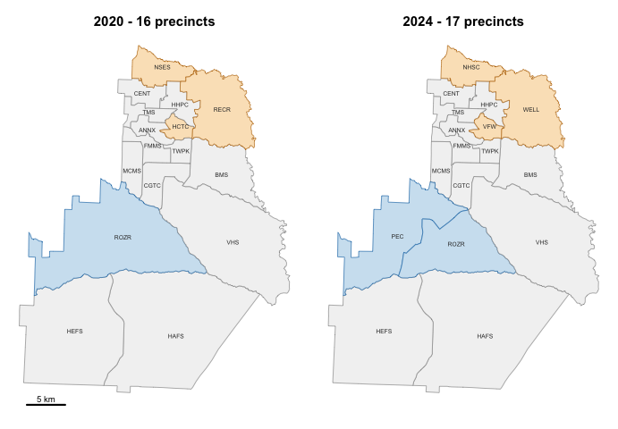

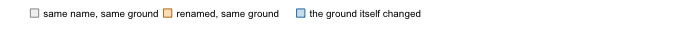

**Figure 1. Houston County’s precincts in 2020 and 2024, with the two kinds of change separated.** A pair of maps, because the claim is about ground and only a map can show ground holding still while names change. Amber areas are the 3 renamed precincts whose boundaries stayed put; blue is ROZR, the one precinct whose ground actually changed; gray kept both name and shape. The 2024 panel counts 17 precincts where the table lists 16; the missing one is PEC, explained below.

The tempting repair, keeping only the precincts whose names match in both years, is exactly wrong. In Houston, name-matching throws away 3 precincts (HCTC, NSES, RECR, carrying 31,161 people), and all three are renames where nothing happened. It keeps ROZR, the one place where something did. Name-matching is a filter on clerical churn, not on boundary change, and a rule whose sign can flip between a county and its state is not a rule to build on.

The fix is the crosswalk built above: newest boundaries as the target, old data broken down onto blocks, blocks added back up inside the new lines. A whole precinct reduced to one interior point can never record a split, which is why PEC is invisible to the precinct-level table; 3,269 blocks, each reduced to a point, can.

Then the choice that moves votes: when a precinct’s ballots travel to more than one successor, in what proportion — by land, or by people?

| Method | Weight is | Houston precincts it calls split | Georgia (%) |
| --- | --- | --- | --- |
| By area | Share of the precinct’s land in each target | 15 of 16 (93.8%) | 78.3 |
| By population | Share of the precinct’s people in each target | 1 of 16 (6.2%) | 18.5 |

The two rules disagree even about how many precincts split at all. Most of area’s extra “splits” are slivers: hairline overlaps where the two files traced the same road a meter apart. Raise the floor to 1% of a precinct and area’s Houston figure falls from 93.8% to 6.2%, exactly matching population. Statewide, a residue of 3.9 points survives the correction: boundaries clipping empty farmland, a split in land that no vote can come from. Where the choice bites is a real split:

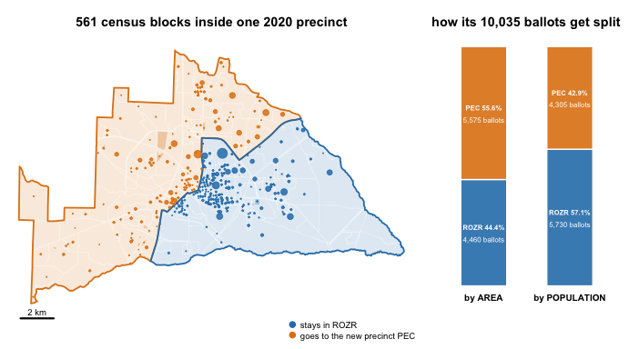

**Figure 2. The one piece of Houston ground that changed precinct, and the 10,035 ballots that have to be divided.** ROZR’s 561 census blocks, each dot sized by population and colored by where its interior point landed in 2024. The western half is big and thinly settled, so land gives PEC 55.6% of ROZR while people give it 42.9%. In ballots: 10,035 × 55.6% = 5,575, against 10,035 × 42.9% = 4,305. The gap is 1,270 ballots, moved from one precinct to another by a methodological choice, with nothing miscounted.

Dots on the dashed diagonal are pairs where land and people give the same answer. Hover a dot for the pair and the gap.

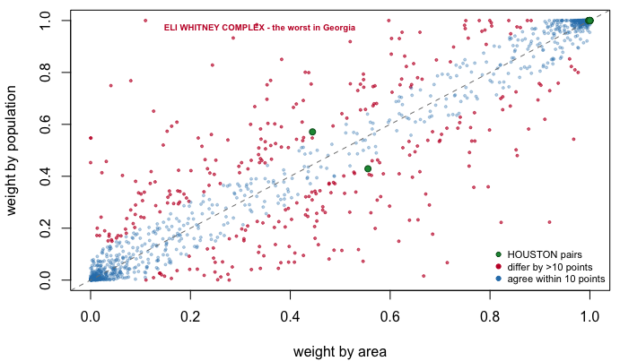

**Figure 3. Where land and people give different answers, across Georgia.** Each point is one 2020-to-2024 precinct pair, placed by its weight under each rule, because the question is agreement and a scatter shows agreement as distance from the diagonal. Of the state’s 3,400 pairs, 324 (9.5%) differ by more than ten points of weight. The labeled extreme, ELI WHITNEY COMPLEX in CHATHAM County, is sent 11.0% of its precinct’s votes by one rule and 100.0% by the other. Houston’s 17 pairs are green; its worst case is the ROZR split.

With a rule chosen, the carry itself is mechanical. It ends with the comparison the opening asked for: Houston’s 2020 presidential vote expressed on Houston’s 2024 map, including PEC, a precinct that did not exist when those votes were cast:

| 2024 precinct | TRUMP20 | BIDEN20 | REG20 | VOTED20 |
| --- | --- | --- | --- | --- |
| BMS | 4,812 | 2,685 | 10,481 | 7,637 |
| MCMS | 4,203 | 2,713 | 9,858 | 7,043 |
| FMMS | 3,439 | 2,983 | 9,567 | 6,551 |
| HHPC | 2,821 | 3,109 | 10,530 | 6,046 |
| ROZR | 3,605 | 2,029 | 8,481 | 5,730 |
| CENT | 3,130 | 2,353 | 8,366 | 5,584 |
| WELLSTON CENTER | 1,087 | 3,878 | 10,539 | 5,054 |
| VHS | 3,164 | 1,578 | 6,735 | 4,820 |
| PEC | 2,709 | 1,525 | 6,372 | 4,305 |
| VFW | 1,909 | 2,022 | 7,184 | 4,021 |
| CGTC | 2,236 | 1,374 | 5,182 | 3,680 |
| TMS | 1,493 | 2,098 | 5,995 | 3,657 |
| ANNX | 2,180 | 1,221 | 4,791 | 3,478 |
| TWPK | 1,868 | 1,328 | 4,757 | 3,278 |
| NORTH HOUSTON SPORT COMPLEX | 1,120 | 676 | 2,596 | 1,825 |
| HAFS | 1,083 | 299 | 1,891 | 1,391 |
| HEFS | 675 | 361 | 1,423 | 1,042 |

A crosswalk that loses votes is worse than none, because it looks fine. So the carry is checked statewide against the totals it started from:

| Check | Value |
| --- | --- |
| 2020 precincts (shapefile) | 2684 |
| carried into the crosswalk | 2653 |
| 2024 precincts receiving votes | 2696 |
| votes before | 13,821,357 |
| votes after | 13,821,335 |
| votes lost | 22 |
| share lost (%) | 0.000 |

22 votes lost out of 13,821,357. The trip can be audited, and this one arrives whole.

## What this brief cannot tell you

**Population is not voters.** The weights count children and non-citizens, and turnout varies inside a precinct in ways a headcount cannot see. Registered voters by block would be the right weight, and nobody publishes it: that is the binding limit here.

**The blocks are older than the boundaries.** Block populations are from the 2020 census; the 2024 lines came later, so growth in between is invisible to the weights — in Houston, precisely the growth that caused the split.

**No number above carries an error bar.** A carried-over total prints with the same authority as a counted one, and in the Houston table 2 of the 17 rows are estimates while nothing in the output says which.

**And one county is one county.** Houston shows the mechanism cleanly because it is simple. The statewide figures above say the rate travels; the anatomy of any other county has to be read the same way, by hand.

## What you should have learned

- Only 84.5% of Georgia’s precinct names survived from 2020 to 2024, and a changed name is usually not a changed boundary: Houston’s 4 changes were 3 renames and 1 real split.
- Keeping only name-matched precincts filters on the wrong thing: in Houston it deletes 3 precincts where nothing happened and keeps the one where something did.
- The weighting choice is not a technicality: land and people disagree by more than ten points of weight on 9.5% of Georgia’s precinct pairs, and in ROZR the choice moves 1,270 ballots.
- A carry can be checked: pushed through the population crosswalk, Georgia’s 2020 vote arrives on the 2024 map with 22 votes lost.

## Extensions

None of these is answered above, and every one can be answered from the tables the Sources section hands over.

- `fig_twosource.csv` compares the shapefile’s precincts against the certified list. Find the precincts in one and not the other. What is a precinct that exists on a map but not in the returns?
- `fig_houston_lab.csv` flags each Houston precinct as kept, renamed or split. Count each kind. What share of the county’s precincts would a name-matcher have compared correctly?
- `fig_rozr_meta.csv` divides ROZR’s ballots two ways and reports both. Compare `ballots_area` against `ballots_pop`. Which assumption would you defend to an editor, and why?
- `fig_rozr_blocks.csv` assigns each of ROZR’s blocks a target precinct and a `pop`. Find the blocks with no people in them. What do empty blocks do to a weighting by area?
- `crosswalk_pop.csv` covers every county, with a `weight` per precinct pair. Pick a county you know and count its precincts that split. Quieter or louder than Houston?

Two stretch ideas point past the spreadsheet. The reapportionment office posts precinct maps back to 2012; download an older pair and measure whether this churn rate is new or normal. And find one county’s own notice of a precinct change, in a board of elections agenda, and check it against what the two maps imply.

## Sources

**Data**

- Georgia Legislative and Congressional Reapportionment Office, *Statewide Voting Precincts*, 2020 and 2024 shapefiles. https://www.legis.ga.gov/joint-office/reapportionment
- U.S. Census Bureau, TIGER/Line 2020, Georgia tabulation blocks (`tl_2020_13_tabblock20`), with 2020 Census population. https://www2.census.gov/geo/tiger/TIGER2020/TABBLOCK20/
- Georgia Secretary of State, certified precinct returns, November 2020 — the independent check on the shapefile’s vote columns. https://sos.ga.gov/page/historical-elections-results
- Houston County Board of Elections publishes its own precinct results at https://www.houstoncountyga.gov/residents/election-results.cms — a third copy of the same numbers, an independent check on any Houston figure above.

**The data itself**

Every figure above is drawn from these tables. They are plain CSV, they open in a spreadsheet, and they are yours to take further.

`fig_houston.csv`, `fig_houston_lab.csv`, `fig_rozr_blocks.csv`, `fig_rozr_meta.csv`, `fig_rozr_outline.csv`, `fig_rozr_pts.csv`, `fig_twosource.csv`, `crosswalk_pop.csv`, `block_assign.csv`

**Method**

- Cervas, J. `assignPolys`, *R-Functions*. https://github.com/jcervas/R-Functions/tree/main/assignPolys
- Amos, B., McDonald, M. P. and Watkins, R. (2017). “When Boundaries Collide: Constructing a National Database of Demographic and Voting Statistics.” *Public Opinion Quarterly* 81(S1): 385–400. doi:10.1093/poq/nfx001; https://election.lab.ufl.edu/data-downloads/census-crosswalk/2020/when_boundaries_collide.pdf
[^1]: The format is Esri’s, and its specification is public: *ESRI Shapefile Technical Description* (1998), https://www.esri.com/content/dam/esrisites/sitecore-archive/Files/Pdfs/library/whitepapers/pdfs/shapefile.pdf.
[^2]: The Bureau’s description of its TIGER/Line files is at https://www.census.gov/geographies/mapping-files/time-series/geo/tiger-line-file.html, and of the census block at https://www.census.gov/programs-surveys/geography/about/glossary.html.
[^3]: The same block-based construction, applied nationally, is described in Brian Amos, Michael P. McDonald and Russell Watkins, “When Boundaries Collide: Constructing a National Database of Demographic and Voting Statistics,” *Public Opinion Quarterly* 81, no. S1 (2017): 385–400, doi:10.1093/poq/nfx001; the authors’ copy is at https://election.lab.ufl.edu/data-downloads/census-crosswalk/2020/when_boundaries_collide.pdf.